# INM430 - Tiny Data Science Project Progress Report

### Student Name : Ryan Nazareth

### Project Title: Use of sports analytics for shot prediction in basketball

# Data source and domain description

This data source has been selected from an educational competition hosted by Kaggle for the data science community. The data source was wrangled from the statistics section of the National Basketball Association (NBA) website and consists of 20 years of data collected from shots made by one of the greatest NBA players,Kobe Bryant, who recently retired from the Los Angeles Lakers in April 2016. The aim is to accurately predict the number of shots which will find the bottom of the net.This type of analysis is being frequently carried out by number of NBA franchises and teams in other sports. The results are normally used for tactical purposes to either gain further insights of perfromances of oppostion players or to track the performance of the club's own players. As basketball players get older, their performance levels tend to drop and may need to be monitored more carefully to help coaches get the best out of the player by altering their workload or playing position.

# Analysis Strategy and Plans

The dataset contains over 20 attributes, some of which include shot type, shot distance, shot coordinates(loc_x and loc_y), latitude and longitude and a binary shot_made_flag which is the label for the dataset indication whether a shot was made or missed. Data cleaning will be carried out in R or Python. Missing values will be removed, features will be expected and removed if not required and PCA willbe carried out to investigate which features controbute most to the variance. Since this is a classification problem, the scikit-learn module in python will be employed to train a number of classification algorithms: SVM, nearest neighbours, ensemble methods using cross validation to then test the model with the best performance. The latidude/longitude and shot coordinates on the court will be used to visualise the correct shots made and shots missed on a map to gain further insights. Other visualisation plots will be used to investigate relationships between shots scored v.s teams played against, type of shot, period of the game, season and time remaining in the game. For this purpose a combination of the visualisation capabilities of Tableau and the ggplot2 package in R will be used.

# Initial investigations on the data sources

# Python code for initial investigations

### Loading in the data set

```python
%matplotlib inline
import numpy as np
import pandas as pd
from sklearn import linear_model,svm,neighbors,decomposition, tree, ensemble
from sklearn.decomposition.pca import PCA
from sklearn.preprocessing import scale
from sklearn import cross_validation
import matplotlib.pyplot as plt

NBA_train = pd.read_csv("data.csv")

NBA_test = pd.read_csv("sample_submission.csv")
NBA_test = NBA_test.drop('shot_made_flag', axis =1) # dropping the shot_made_flag which were set as 0.5 for all the shot IDs

print(NBA_train.head())
print(NBA_test.head())
```

```
         action_type combined_shot_type  game_event_id   game_id      lat  \
0          Jump Shot          Jump Shot             10  20000012  33.9723
1          Jump Shot          Jump Shot             12  20000012  34.0443
2          Jump Shot          Jump Shot             35  20000012  33.9093
3          Jump Shot          Jump Shot             43  20000012  33.8693
4  Driving Dunk Shot               Dunk            155  20000012  34.0443

   loc_x  loc_y       lon  minutes_remaining  period   ...          shot_type  \
0    167     72 -118.1028                 10       1   ...     2PT Field Goal
1   -157      0 -118.4268                 10       1   ...     2PT Field Goal
2   -101    135 -118.3708                  7       1   ...     2PT Field Goal
3    138    175 -118.1318                  6       1   ...     2PT Field Goal
4      0      0 -118.2698                  6       2   ...     2PT Field Goal

          shot_zone_area  shot_zone_basic  shot_zone_range     team_id  \
```

[output cut: 20 more lines]

### Counting the number of missing values

```python
Missing_values = NBA_train.shape[0] - NBA_train.count() # these 5000 missing values correspond to the shotmade flag which need to be predicted

print(Missing_values) # 5000 missing values correspond to the shotmade flag attributes which are stored in NBA_test and need to be predicted so we will drop them from the training set
```

```
action_type              0
combined_shot_type       0
game_event_id            0
game_id                  0
lat                      0
loc_x                    0
loc_y                    0
lon                      0
minutes_remaining        0
period                   0
playoffs                 0
season                   0
seconds_remaining        0
shot_distance            0
shot_made_flag        5000
shot_type                0
shot_zone_area           0
shot_zone_basic          0
shot_zone_range          0
team_id                  0
team_name                0
game_date                0
matchup                  0
opponent                 0
shot_id                  0
dtype: int64
```

### Dropping missing values rows which correspond to the data in the test set

```python
NBA_train = NBA_train.dropna(subset =['shot_made_flag'])

print(NBA_train['shot_made_flag'].isnull().sum()) # check to see that new training data set contains no missing values now
```

```
0
```

### Dropping columns which are not required or redundant

```python
NBA_train.drop(NBA_train.columns[[0,1,2,3,10, -3,-4,-5,-6,-7,-8,-9]],axis=1, inplace=True) # #Dropping columns we are not interested e.g. categorical descriptive
```

### Visualising total shots made (scored and missed) using loc-x, loc-y coordinate system and lon/lat coordinate system

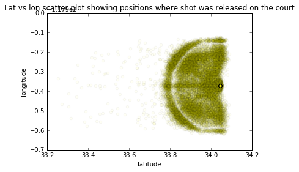

```python
lon = NBA_train['lon']
lat = NBA_train['lat']
loc_x = NBA_train['loc_x']
loc_y = NBA_train['loc_y']

## Visualising what locx locy lat and lon represent
plt.figure(1)
plt.scatter(lat,lon, c =(1,1,0,),marker ='o', alpha=0.04 )  # scatter plot of court
plt.title('Lat vs lon scatter plot showing positions where shot was released on the court')
plt.xlabel('latitude')
plt.ylabel('longitude')
```

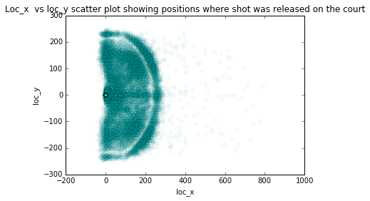

```python
plt.figure(2)
plt.scatter(loc_y,loc_x,  c = (0,1,1), marker ='o',alpha =0.04)
plt.title('Loc_x  vs loc_y scatter plot showing positions where shot was released on the court')
plt.xlabel('loc_x')
plt.ylabel('loc_y')

# This represents a semi circle- the boundary of which represents the 3 point line. Correct shots made wthin this region are worth 2 points, and outside are worth 3 points.so locx loc y lat and lon correspond to the coordinates on the court from where the ball was shot by Kobe. Looks like locx,locy give the same information as lat and lon
```

### Visualising shots scored using lon/lat coordinate system

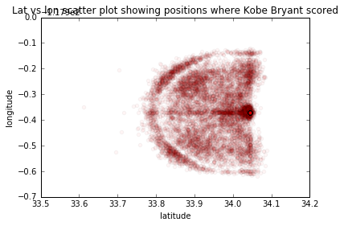

```python
coordinates = NBA_train[['lat','lon','shot_made_flag']] #lets append the locx and locy data along with the shots made flag to a new array called coordinates
plt.figure(3)
coordinates_scored = coordinates[coordinates.shot_made_flag == 1]

plt.scatter(coordinates_scored['lat'],coordinates_scored['lon'], c = (1,0,0), marker ='o', alpha=0.04,)  # scatter plot of court
plt.title('Lat vs lon scatter plot showing positions where Kobe Bryant scored')
plt.xlabel('latitude')
plt.ylabel('longitude')
```

### Preparing data for Principal Component Analysis

```python
NBA_train['season'] = NBA_train['season'].map(lambda x: x[0:4]).astype(np.int64) # Converting the year range in the season column to a single year by stripping character following hyphen


train_PCA = NBA_train.values  #Preparing data for PCA : we need to convert data frame into array

train_PCA = train_PCA[:,[4,5,6,7,8]] # extracting non categorical columns from array as PCA only recognises numbers. Alse excluded the labels (shot_made_flag)

pca = PCA(n_components=5) # the components are mins remaining, period, season,seconds remaining and shot distance

train_PCA_var = pca.fit_transform(scale(train_PCA)) # scaling the columns so they all have the same range before PCA and then applying the transformation

varianceratio = pca.explained_variance_ratio_
print(' ')
print(pca.explained_variance_ratio_) # prints array with componets with highest variance ratio in descending order
print(' ')

train_PCA_cumsum_var = np.cumsum(np.round(pca.explained_variance_ratio_, decimals=4)*100)

print(' ')
print(train_PCA_cumsum_var) # prints array with cummulative variance for the 5 components
print(' ')
```

```
[ 0.23251859  0.20671151  0.20093317  0.18885612  0.17098061]


[  23.25   43.92   64.01   82.9   100.  ]
```

### Plotting varaince ratio and cumulative variance for the components

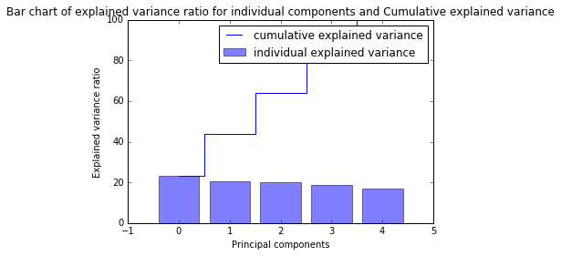

```python
with plt.style.context('seaborn-whitegrid'):
    plt.figure(4)

plt.bar(range(len(varianceratio)), (100*varianceratio), alpha=0.5, align='center',
label='individual explained variance')
plt.step(range(len(train_PCA_cumsum_var)), (train_PCA_cumsum_var), where='mid',
label='cumulative explained variance')
plt.title('Bar chart of explained variance ratio for individual components and Cumulative explained variance')
plt.ylabel('Explained variance ratio')
plt.xlabel('Principal components')
plt.legend(loc='best')
#plt.tight_layout()
```

### Scatter plot of principal component 1 vs principal component 2

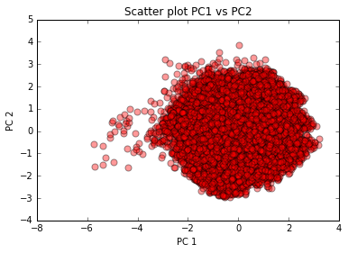

```python
# we see that each attribute contributes roughly 20% of the variance in the data are are almost equally important. So we will use all 5 features for the subsequent modelling steps

plt.figure(5)
plt.scatter(train_PCA_var[:,0], train_PCA_var[:,1],marker = 'o', c =(1,0,0),s =50, alpha =0.4)
plt.title("Scatter plot PC1 vs PC2")
plt.xlabel("PC 1 ")
plt.ylabel("PC 2")
```